# FLIC: Data Analysis Part 2: Grouped Analysis and Treatments

Scott Pletcher and the Pletcher Lab

04/20/2020 (Version 4.x)

## Overview

This document describes the most common functions that we have written to manage groups of DFMs, which may or may not be associated with each other as part of an experimental design. Function whose name ends in *.Monitors()* act on groups of DFM and may or may not accept an optional experimental design argument. Most other high-level analysis functions will require an experimental design argument and will allow more complicated representation of different treatments, across DFMs and chambers.

As with all FLIC R code, this is a work in progress. If you decide to extend this code and wish to share it with the community, please contact Scott.

First, we will attach the FLICFunctions object and load the required libraries.

```r
library(ggplot2)
library(stats)
library(gridExtra)
library(reshape2)
attach("FLICFunctions",pos=2)
```

## DFM Groups Without Design Structure

When *Monitors* functions are used without an experimental design argument, they effectively serve to batch process the functions that operate on individual DFMs, which are described in the *Getting Started* document. For these functions you must provide a vector of integers whose elements enumerate the DFM IDs that you wish to analyze. You must also supply either a single parameters object or a list of parameters objects. If a single parameters object is provided, then it will be applied to all of the monitors in the list. If a list of parameters objects is provided, then it must be the same length as the monitors list, and each parameter object will be applied to its respective DFM. As usual, a range may be specificed (in minutes) if desired. These batch functions can take a significant amount of time to run (sometimes many hours) if you have several DFMs and more than 48 hours of data. Remember that each DFM reports 5,184,000 signal values in 24 hours (it actually samples from the feeding pad 200x more often than that)!

The examples in this document use actual DFM data from two different experiments. First, we will examine the data from a single-well experiment that used four DFMs (DFM1 - DFM4). This experiment lasted 1080 minutes (18 hours). The second experiment that we will examine is a choice experiment that used seven DFMs (DFM11 - DFM17). It lasted 360 minutes (6 hours).

It is important to recognize three terms in this document and in the relevant data output, all of which refer in some way to the individual food wells or the overall feeding environment. First,*Well Number* refers to the physical position of the food well on the DFM. For any specific well, this number does not change and is independent of the type of experiment or lid. At present, for all DFM versions the wells are numbered 1-12 from left to right and top to bottom. Second, the term *Chamber* refers to the physical space that a fly (or small number of flies) experience. When obtained from our laboratory or from Sable Systems, the FLIC system includes lids that define 12 chambers (one food well in each chamber) or six chambers (choice chambers with two food wells in each chamber, one on the left and one on the right). Third, choice experiments (but not single-well experiments) identify *WellA* and *WellB*, where a preference index of PI = 1 indicates feeding 100% from *WellA*, and PI = -1 indicates 100% feeding on *WellB*. These wells are defined based on the *PI.Multiplier* parameter in a parameters object for a particular DFM. *WellA* will be the left well of a two-well chamber if *PI.Multiplier* = 1, and it will be the right well if *PI.Multiplier* = -1.

Let’s first load in the data for our two experiments. For the single-well experiment we will accept the default set of parameters and define the list of monitors

```r
p.single<-ParametersClass.SingleWell()
monitors.single<-c(1,2,3,4)
```

The choice experiment followed good design principles and swapped the food wells (sucrose vs. denatonium) on different DFM. On DFMs 11, 13, 15, and 17, denatonium food was made available from the right well in each chamber with standard sucrose food on the left. In DFMs 12, 14, and 16, the food was switched such that denatonium was present on the left side and sucrose on the right. We will choose to present the data in terms of preference FOR denatonium, because flies normally will avoid this bitter substance. Thus, we will set PI.Multiplier to 1 when denatonium is present in the left well and -1 when it is present in the right well. As a result, ‘WellA’ will always refer to wells with denatonium (‘WellB’ will always refer to sucrose only), regardless of the physical position of the well in the specific DFM.

To accomplish this we will create two different parameters objects that will be identical except for the PI.Multiplier. Then we will define a list of parameter objects whose components will be associated with each monitor, repectively.

```r
p.choice.one<-ParametersClass.TwoWell()
p.choice.two<-ParametersClass.TwoWell()
p.choice.two<-SetParameter(p.choice.two,PI.Multiplier=-1.0)
monitors.choice<-c(11,12,13,14,15,16,17)
p.choice.list<-list(p.choice.two,p.choice.one,p.choice.two,p.choice.one,p.choice.two,p.choice.one,p.choice.two)
```

In general, *.Monitors()* functions will automatically read in DFM data if needed (i.e., if a background DFM object is not already present). So there is no need to load them with separate *DFMClass()* statements. The functions will also update background DFM objects with new parameter values if those specified are different from those in the existing DFM object. Behind the scences, these functions effectively call *DFMClass()* for each monitor (see *Getting Started* documentation for details).

Currently, single-well and choice experiments can not be analyzed in a single list. They must be analyzed as separate groups such that any single function call manages only single-well or only choice DFMs. If you have a mixture, simply examine them separately as we do in this example.

To output the baselined data for a group of DFM use the *OutputData.Monitors(monitors,parameters,expDesign=NA,range=c(0,0),Type=“BaselinedData”,filename=NA)* function and accept the default data *Type=“BaselinedData”*. Because these *.csv* files can be very large, a separate file is saved for each DFM. The files will be formatted similarly for single-well and choice experiments. Data columns in the output file are self-explanatory. Console output will report progress because the functions can take quite some time to complete.

```r
OutputData.Monitors(monitors.single,p.single)
```

```
## [1] "Outputting Baselined Data for DFM 1."
## [1] "Outputting Baselined Data for DFM 2."
## [1] "Outputting Baselined Data for DFM 3."
## [1] "Outputting Baselined Data for DFM 4."
```

```r
## The next call applies parameters objects to DFM objects elementwise.
OutputData.Monitors(monitors.choice,p.choice.list, range=c(0,15))
```

```
## [1] "Outputting Baselined Data for DFM 11."
## [1] "Outputting Baselined Data for DFM 12."
## [1] "Outputting Baselined Data for DFM 13."
## [1] "Outputting Baselined Data for DFM 14."
## [1] "Outputting Baselined Data for DFM 15."
## [1] "Outputting Baselined Data for DFM 16."
## [1] "Outputting Baselined Data for DFM 17."
```

Other aspects of the data can also be saved to a *.csv* file in the same manner by changing the *Type* argument in the function call. Available options (as of version 4.0) are *“BaselinedData”*, *“Durations”*, *“TimeBtw”*, and *“TotalFeeding”*. *Durations* describes details about individual events, focussing on thier lenght in seconds. *TimeBtw* describes details of the intervals that separate feeding events, and *TotalFeeding* outputs the total time flies interacted with each food well over entire experiment (or timer period defined by the *range* argument). Examples are given below. As with most functions, a range parameter can be provided to limit the output to a specific time period in the experiment. A filename can also be given if the default is not adequate.

```r
OutputData.Monitors(monitors.single,p.single,Type="Durations",filename="SingleDurations")
OutputData.Monitors(monitors.choice,p.choice.list,Type="Durations",filename="ChoiceDurations")
```

```r
OutputData.Monitors(monitors.single,p.single,Type="TimeBtw",filename="SingleIntervals")
OutputData.Monitors(monitors.choice,p.choice.list,Type="TimeBtw",filename="ChoiceIntervals")
```

```r
OutputData.Monitors(monitors.single,p.single,range=c(0,600),Type="TotalFeeding",filename="SingleTotal")
OutputData.Monitors(monitors.choice,p.choice.list,range=c(0,600),Type="TotalFeeding",filename="ChoiceTotal")
```

*Durations*, *TimeBtw*, and *TotalFeeding* data is more condensed than the raw data, so these options collect multiple DFMs into a single file and append a column to indicate the appropriate DFM. Both functions also report data for Well Number, which represents the physical location of the well and which is not adjusted for PI.Multiplier. For choice chambers, there is a TCWell column that has incorporated the PI.Multiplier information and therefore indicates values of ‘WellA’ or ‘WellB’.

*Feeding.Summary.Monitors* is the first of two key analysis functions. This function calculates feeding summary data for a group of DFMs, which can optionally be output to a .csv file (if *SaveToFile=TRUE*) and/or returned as an object. For reasons that will become clear when we introduce treatment-based analyses below, the results are obtained from the *$Results* component of the returned object.

```r
f.summary<-Feeding.Summary.Monitors(monitors.single,p.single,SaveToFile = TRUE)
f.summary2<-Feeding.Summary.Monitors(monitors.choice,p.choice.list,SaveToFile = TRUE)
head(f.summary$Results[,1:12])
```

```
##   DFM Chamber     Licks Events MeanDuration MedDuration MeanTimeBtw
## 1   1       1  7.448471    416     1.550481         1.0   153.64412
## 2   1       2  7.381635    199     3.115578         2.8   320.47300
## 3   1       3  8.397589    535     1.968972         1.4   118.77090
## 4   1       4  6.630678    145     2.762759         2.0   440.50685
## 5   1       5  6.565404    141     2.807092         2.0   452.94930
## 6   1       6 10.159875   1124     2.001779         1.4    55.52409
##   MedTimeBtw  MeanInt MedianInt MinInt MaxInt
## 1       98.2 35.31597        28     -1    164
## 2      132.3 43.51387        36      0    218
## 3       75.1 25.54110        22     -1    115
## 4       66.0 38.98003        31     -1    166
## 5      132.5 39.84234        27     -1    242
## 6       33.0 25.19324        23     -1    147
```

Please remember that the default behavior here is to transform the number of licks to the 0.25 power. Refer to the *Getting Started* document for an explanation of each summary metric in the returned objects. For choice chambers, there are values included for WellA and WellB that are adjusted for PI.Multiplier.

```r
head(f.summary2$Results[,c(1:24)])
```

```
##   DFM Chamber         PI    EventPI   LicksA   LicksB EventsA EventsB
## 1  11       1 -0.5913978 -0.2577320 3.267580 4.590349      36      61
## 2  11       2  0.4938373  0.6280702 6.529779 4.981902     232      53
## 3  11       3 -0.8095238 -0.3548387 2.165737 3.802214      10      21
## 4  11       4  0.5179487  0.4877193 6.491734 4.873262     212      73
## 5  11       5 -0.9636364 -0.8888889 1.414214 3.833659       1      17
## 6  11       6 -0.9322034 -0.8260870 1.861210 4.300377       2      21
##   MeanDurationA MedDurationA MeanDurationB MedDurationB MeanTimeBtwA
## 1     0.6666667          0.4      1.475410          1.2    581.49189
## 2     1.7000000          1.2      2.505660          1.8     90.75021
## 3     0.4400000          0.4      2.066667          2.2   1957.70909
## 4     1.8518868          1.0      1.654795          1.2     99.27981
## 5     0.8000000          0.8      2.764706          2.8  10769.20000
## 6     1.2000000          1.2      3.571429          2.6   7178.93333
##   MedTimeBtwA MeanTimeBtwB MedTimeBtwB MeanIntA MedianIntA MinIntA MaxIntA
## 1        53.8     345.9548       167.1 20.98333       21.0      -1      42
## 2         6.8     396.4148       180.6 40.22008       39.0      -1     146
## 3       177.4     977.0818       104.3 22.68182       19.0      11      60
## 4         5.6     289.4378       196.7 45.67091       44.0      -1     170
## 5     10769.2    1194.0111       234.3 29.25000       28.5      26      34
## 6      7822.6     975.6455       264.1 30.25000       24.5      13      82
##   MeanIntB MedianIntB MinIntB MaxIntB
## 1 46.27333         37       4     195
## 2 46.94880         40       0     189
## 3 45.18433         39       0     157
## 4 63.44040         52      -1     276
## 5 42.90638         40       0     130
## 6 41.85333         41       0     129
```

Notice that each DFM has an PI.Multiplier referenced as part of the output. It is good to check this to ensure the parameters objects were assigned correctly.

```r
head(f.summary2$Results)
```

```
##   DFM Chamber         PI    EventPI   LicksA   LicksB EventsA EventsB
## 1  11       1 -0.5913978 -0.2577320 3.267580 4.590349      36      61
## 2  11       2  0.4938373  0.6280702 6.529779 4.981902     232      53
## 3  11       3 -0.8095238 -0.3548387 2.165737 3.802214      10      21
## 4  11       4  0.5179487  0.4877193 6.491734 4.873262     212      73
## 5  11       5 -0.9636364 -0.8888889 1.414214 3.833659       1      17
## 6  11       6 -0.9322034 -0.8260870 1.861210 4.300377       2      21
##   MeanDurationA MedDurationA MeanDurationB MedDurationB MeanTimeBtwA
## 1     0.6666667          0.4      1.475410          1.2    581.49189
## 2     1.7000000          1.2      2.505660          1.8     90.75021
## 3     0.4400000          0.4      2.066667          2.2   1957.70909
## 4     1.8518868          1.0      1.654795          1.2     99.27981
## 5     0.8000000          0.8      2.764706          2.8  10769.20000
## 6     1.2000000          1.2      3.571429          2.6   7178.93333
##   MedTimeBtwA MeanTimeBtwB MedTimeBtwB MeanIntA MedianIntA MinIntA MaxIntA
```

[output cut: 34 more lines]

One strength of the FLIC system is to monitor time-dependent behavior and to identify differences in feeding behaviors as a function of time of day or before and after a specific manipulation. We saw a simple implementation of this in the *Getting Started* document using the *BinnedLicksPlot.DFM()* and *BinnedFeeding.Summary.DFM()* functions. By extending this to batch process groups of monitors, *BinnedFeeding.Summary.Monitors()*, which is the second of the two key analysis functions, works similarly to *Feeding.Summary.Monitors()*, but it groups (i.e., adds together) Licks and Events that occur together within fixed sized bins. Bin size is defined in minutes and passed as a required *binsize.min* argument.

```r
f.binsummary<-BinnedFeeding.Summary.Monitors(monitors.single,p.single,binsize.min=30,SaveToFile = TRUE)
f.binsummary2<-BinnedFeeding.Summary.Monitors(monitors.choice,p.choice.list,binsize.min=30,SaveToFile = TRUE)
head(f.binsummary$Results[,1:6])
```

```
##   Interval Minutes DFM Chamber    Licks Events
## 1   [0,30]      15   1       1 3.260390     15
## 2   [0,30]      15   1       2 3.860008     24
## 3   [0,30]      15   1       3 3.253153     15
## 4   [0,30]      15   1       4 3.517004     19
## 5   [0,30]      15   1       5 0.000000      0
## 6   [0,30]      15   1       6 3.567621     17
```

```r
head(f.binsummary2$Results[,1:8])
```

```
##   Interval Minutes DFM Chamber         PI    EventPI   LicksA   LicksB
## 1   [0,30]      15  11       1 -1.0000000 -1.0000000 0.000000 2.560750
## 2   [0,30]      15  11       2 -1.0000000 -1.0000000 0.000000 2.114743
## 3   [0,30]      15  11       3 -0.7681159 -0.4000000 1.681793 2.794682
## 4   [0,30]      15  11       4  0.5659574  0.4634146 3.683023 2.672345
## 5   [0,30]      15  11       5        NaN        NaN 0.000000 0.000000
## 6   [0,30]      15  11       6 -1.0000000 -1.0000000 0.000000 1.861210
```

The *Interval* column contains the boundary times in minutes for each interval (open on the left and closed on the right). The *Minutes* column contains the midpoints of the intervals (in minutes).

**NOTE:** It is absolutely critical that you understand how parameters objects are assigned to DFMs and that you get the parameter values and PI.Multipliers correct for each DFM. Otherwise, your feeding data will be incorrect, and differences among chambers and among treatments will be obfuscated. If you do get it wrong, it will not necessarily be obvious from the plots or from the data output, given the size and complexity of the FLIC data. Please evaluate the summary data and ensure that it matches your expectations and the expectations generated from examination of the individual DFMs, as described in the *Getting Started* document. It is at this point that you should take your time and be certain the data are properly loaded and summarized. Only after you are comfortable should you move on to explore the experiments in different ways using the higher-level functions (described below), the functions that evaluate preference (see *Analysis of Choice Experiments* document), and the advanced functions for specialized analyses (see *Additional Analyses* document).

## Treatment-Based Analysis

#### Feeding Summary

Some *.Monitors()* functions accept an experimental design data frame for treatment-based analysis. Most other *front-end* functions in the *FLICUserFunctions.R* file require it as well. Functions that accept this as an optional parameter can be identified by the presence of a *expDesign=NA* argument in their function definition. For example,

```r
head(Feeding.Summary.Monitors)
```

```
##
## 1 function (monitors, parameters, expDesign = NA, range = c(0,
## 2     0), SaveToFile = TRUE, TransformLicks = TRUE, filename = "FeedingSummary")
## 3 {
## 4     individ.params <- FALSE
## 5     if (is.list(parameters[[1]]) == TRUE) {
## 6         if (length(parameters) != length(monitors))
```

```r
head(DivisionPlots)
```

```
##
## 1 function (monitors, parameters, expDesign, range = c(0, 0), divisions = 1,
## 2     Type = "Licks", SaveToFile = FALSE, TransformLicks = TRUE)
## 3 {
## 4     if (is.list(parameters[[1]])) {
## 5         cs <- parameters[[1]]$Chamber.Size
## 6     }
```

In short, adding an experimental design argument to these functions modifies the output files to make it easier to analyze treatment-level differences in other software and to provide simple plotting capabilities that visualize differences among different genotypes, environments, and other manipulations.

An experimental design object is usually derived from a .csv file that contains several rows (one each for each chamber for each DFM in the experiment) and three columns, which are defined as

| DFM | Chamber | Treatment |
| --- | --- | --- |
| DFMID (integer) | Chamber number (integer,1-6/1-12) | Treatment name (no whitespace or special characters) |

There must be one and only one row for each chamber in the experiment. Single-well experiments will have twelve rows per DFM (in this case the chamber number is equal to the well number and ranges from 1-12). For choice experiments, there will be six chambers, numbered 1-6 from the top of the DFM to the bottom. You may have extra rows in the file as long as these extra rows do not duplicate DFM IDs or chamber numbers. So, for our example, we have created a single experimental design file for both our single-well and choice experiments. The DFM IDs are all different so this does not create any conflicts. The easiest way to create the design file is to use excel or other spreadsheet software and to save the files as *.csv*. The design is then read into R using the *read.csv()* function.

```r
expDesign<-read.csv("ExpDesign.csv")
expDesign
```

```
##    DFM Chamber  Treatment
## 1   11       1 Activated1
## 2   11       2 Activated2
## 3   11       3   Control2
## 4   11       4 Activated1
## 5   11       5 Activated2
## 6   11       6   Control1
## 7   12       1 Activated2
## 8   12       2   Control1
## 9   12       3   Control2
## 10  12       4   Control2
## 11  12       5   Control1
## 12  12       6 Activated1
## 13  13       1 Activated2
## 14  13       2 Activated1
```

[output cut: 76 more lines]

For those that are interested, these experiments were executed using the FLIC OptoLid accessory that provides closed- and open-loop optostimulation of individual flies in response to specific feeding behaviors (for more details contact Scott). The single-well experiment involves sporatic, brief optostimulation and measures the effect on total feeding. The choice experiment is closed-loop and measures the effect of targeted optostimulation, in which flies are stimulated only when feeding on a distasteful food (i.e., one that contains denatonium). The question is whether paired optostimulation changes the flies preference and willingness to feed on the denatonium food.

Executing the *Feeding.Summary.Monitors()* function with an experimental design argument creates a second output file (if *SaveToFile=TRUE*) and adds more information to the returned object.

```r
#Function Definition
#Feeding.Summary.Monitors<-function(monitors,parameters,expDesign=NA,range=c(0,0),SaveToFile=TRUE,TransformLicks=TRUE,filename="FeedingSummary")
f.summary<-Feeding.Summary.Monitors(monitors.single,p.single,expDesign=expDesign,SaveToFile = TRUE)
f.summary2<-Feeding.Summary.Monitors(monitors.choice,p.choice.list,,expDesign=expDesign,SaveToFile = TRUE)
head(f.summary$Results[,1:10])
```

```
##    Treatment DFM Chamber     Licks Events MeanDuration MedDuration
## 1 Activated1   1       1  7.448471    416     1.550481         1.0
## 2   Control2   1       2  7.381635    199     3.115578         2.8
## 3 Activated1   1       3  8.397589    535     1.968972         1.4
## 4   Control2   1       4  6.630678    145     2.762759         2.0
## 5   Control1   1       5  6.565404    141     2.807092         2.0
## 6 Activated1   1       6 10.159875   1124     2.001779         1.4
##   MeanTimeBtw MedTimeBtw  MeanInt
## 1   153.64412       98.2 35.31597
## 2   320.47300      132.3 43.51387
## 3   118.77090       75.1 25.54110
## 4   440.50685       66.0 38.98003
## 5   452.94930      132.5 39.84234
## 6    55.52409       33.0 25.19324
```

[output not shown]

The *f.summary* and *f.summary2* objects contain two elements. The *$Results* element is similar to what we examined for the function call without a design argument (see above), with one exception. A specific treatment is now associated with each chamber in each DFM, and this information is encoded as a new column in the data frame. The new column is a “factor” and can be used in simple ANOVA and other analyses to determine whether there are significant differences among treatments for any of the individual behavior metrics.

```r
summary(aov(Licks~Treatment,data=f.summary$Results))
```

```
##             Df Sum Sq Mean Sq F value   Pr(>F)
## Treatment    3  177.1   59.05   15.86 3.91e-07 ***
## Residuals   44  163.8    3.72
## ---
## Signif. codes:  0 '***' 0.001 '**' 0.01 '*' 0.05 '.' 0.1 ' ' 1
```

```r
summary(aov(MeanTimeBtw~Treatment,data=f.summary$Results))
```

```
##             Df    Sum Sq   Mean Sq F value  Pr(>F)
## Treatment    3 4.223e+09 1.408e+09   5.628 0.00236 **
## Residuals   44 1.101e+10 2.501e+08
## ---
## Signif. codes:  0 '***' 0.001 '**' 0.01 '*' 0.05 '.' 0.1 ' ' 1
```

```r
summary(aov(LicksA~Treatment,data=f.summary2$Results))
```

```
##             Df Sum Sq Mean Sq F value   Pr(>F)
## Treatment    3  126.3   42.10   9.611 7.45e-05 ***
## Residuals   38  166.4    4.38
## ---
## Signif. codes:  0 '***' 0.001 '**' 0.01 '*' 0.05 '.' 0.1 ' ' 1
```

If you are interested in asking whether there are significant differences among DFM, then you will need to ensure DFM is treated as a factor. Because it is encoded as an integer by default, it will be treated as a continuous variable, and the ANOVA will be incorrect.

```r
summary(aov(Licks~DFM,data=f.summary$Results))
```

```
##             Df Sum Sq Mean Sq F value Pr(>F)
## DFM          1     13  12.963   1.818  0.184
## Residuals   46    328   7.129
```

Notice only one degree of freedom for DFM, despite there being four DFM in the single-well experiment. The correct way to do this analysis is to ensure R treats DFM as a factor (a similar procedure should be used for Chamber or Well numbers also).

```r
summary(aov(Licks~factor(DFM),data=f.summary$Results))
```

```
##             Df Sum Sq Mean Sq F value Pr(>F)
## factor(DFM)  3   17.5   5.844   0.795  0.503
## Residuals   44  323.4   7.350
```

In addition to the original *.csv* file and the *Results* element, a second file and element are created and returned, respectively, that provide the mean and standard error of the mean (SEM) across all treatments for each behavior metric. This information can be accessed by examining the *Stats* component of the returned object (or the corresponding *_Stats.csv* file that is saved in the current working directory.)

```r
head(f.summary$Stats)
```

```
##    Treatment    Licks   Events MeanDuration MedDuration MeanTimeBtw
## 1 Activated1 9.180783 838.9167     1.923459    1.316667    90.13026
## 2 Activated2 9.069181 883.7500     1.920071    1.325000   114.71181
## 3   Control1 4.552722 108.9167     2.014923    1.450000 21888.82197
## 4   Control2 6.556130 147.2500     2.728774    2.150000   484.32054
##    MedTimeBtw  MeanInt MedianInt    MinInt    MaxInt  LicksSEM EventsSEM
## 1    54.48333 28.94764  25.66667 -2.666667 137.50000 0.2821049 109.12298
## 2    60.68333 34.48359  30.83333 -1.500000 184.50000 0.3425945 133.74462
## 3 21650.85000 20.80365  16.29167 -0.500000  92.16667 1.0000749  30.71878
## 4   127.85833 38.51209  30.75000 -0.500000 174.75000 0.2088344  13.18236
##   MeanDurationSEM MedDurationSEM MeanTimeBtwSEM MedTimeBtwSEM MeanIntSEM
## 1      0.08070723     0.07571211       11.16692      7.467666   1.473177
## 2      0.14292156     0.12005365       31.88869     17.535859   1.681049
## 3      0.44626467     0.32671459     9130.59633   9181.226990   4.626363
## 4      0.12208599     0.12583057       54.55721     16.120425   1.838082
```

[output cut: 20 more lines]

```r
head(f.summary2$Stats)
```

```
##    Treatment          PI     EventPI   LicksA   LicksB  EventsA  EventsB
## 1 Activated1 -0.11566662 -0.01537433 4.735031 4.726532 182.5455 67.45455
## 2 Activated2 -0.07215008 -0.04098063 5.015331 4.783242 218.5455 68.27273
## 3   Control1 -0.88242713 -0.78067448 1.295414 3.319094   2.6000 18.60000
## 4   Control2 -0.89540403 -0.69399014 1.530198 3.605431   4.3000 19.20000
##   MeanDurationA MedDurationA MeanDurationB MedDurationB MeanTimeBtwA
## 1     1.3078018    0.9181818      1.807961     1.454545     1336.114
## 2     1.4912150    1.0272727      2.086056     1.654545     3146.846
## 3     0.5933333    0.5700000      1.804980     1.400000    10646.071
## 4     0.4507460    0.3800000      1.989979     1.740000     7464.917
##   MedTimeBtwA MeanTimeBtwB MedTimeBtwB MeanIntA MedianIntA  MinIntA
## 1    554.3818     420.2214    220.3364 27.92468   26.54545 3.090909
## 2   2289.5455     503.3391    185.0818 30.39793   29.40909 6.181818
## 3  10739.6800    3080.3619   2427.1200 17.14383   16.30000 8.000000
## 4   5958.5000    1285.6776    242.7700 17.18348   16.30000 8.600000
```

[output cut: 40 more lines]

Columns for each metric are given for the mean values and the standard error of the mean (SEM). Notice that for choice experiments, each metric is given with respect to Well A and Well B, which are adjusted for the PI.Multiplier. As always, the current parameter values are appended as additional columns to each output for reference.

#### Binned Feeding Summary

As discussed above, the *BinnedFeeding.Summary.Monitors()* function extends *Feeding.Summary.Monitors()*, and it can also accept an experimental design argument to append treatments to outputs and to provide summary statistics for each interval. If *SaveToFile=TRUE*, data and summary *.csv* files are saved.

```r
#Function Definition
#BinnedFeeding.Summary.Monitors<-function(monitors,parameters,binsize.min=30,expDesign=NA,range=c(0,0),SaveToFile=TRUE,TransformLicks=TRUE,filename="BinnedSummary")
f.binsummary<-BinnedFeeding.Summary.Monitors(monitors.single,p.single,binsize.min=30,expDesign=expDesign,SaveToFile = TRUE)
f.binsummary2<-BinnedFeeding.Summary.Monitors(monitors.choice,p.choice.list,binsize.min=30,expDesign=expDesign,SaveToFile = TRUE)
head(f.binsummary$Results[,1:7])
```

```
##    Treatment Interval Minutes DFM Chamber    Licks Events
## 1 Activated1   [0,30]      15   1       1 3.260390     15
## 2   Control2   [0,30]      15   1       2 3.860008     24
## 3 Activated1   [0,30]      15   1       3 3.253153     15
## 4   Control2   [0,30]      15   1       4 3.517004     19
## 5   Control1   [0,30]      15   1       5 0.000000      0
## 6 Activated1   [0,30]      15   1       6 3.567621     17
```

```r
head(f.binsummary2$Results[,1:9])
```

```
##    Treatment Interval Minutes DFM Chamber         PI    EventPI   LicksA
## 1 Activated1   [0,30]      15  11       1 -1.0000000 -1.0000000 0.000000
## 2 Activated2   [0,30]      15  11       2 -1.0000000 -1.0000000 0.000000
## 3   Control2   [0,30]      15  11       3 -0.7681159 -0.4000000 1.681793
## 4 Activated1   [0,30]      15  11       4  0.5659574  0.4634146 3.683023
## 5 Activated2   [0,30]      15  11       5        NaN        NaN 0.000000
## 6   Control1   [0,30]      15  11       6 -1.0000000 -1.0000000 0.000000
##     LicksB
## 1 2.560750
## 2 2.114743
## 3 2.794682
## 4 2.672345
## 5 0.000000
## 6 1.861210
```

```r
head(f.binsummary$Stats[,1:7])
```

```
##    Interval  Treatment Minutes    Licks   Events MeanDuration MedDuration
## 1    [0,30] Activated1      15 3.452000 18.16667     1.773081    1.416667
## 2   (30,60] Activated1      45 3.768255 25.41667     1.998185    1.341667
## 3   (60,90] Activated1      75 3.558093 20.33333     1.988192    1.625000
## 4  (90,120] Activated1     105 3.583980 22.16667     1.829198    1.200000
## 5 (120,150] Activated1     135 3.660165 21.50000     1.902167    1.425000
## 6 (150,180] Activated1     165 3.771540 23.08333     1.966609    1.433333
```

```r
head(f.binsummary2$Stats[,1:11])
```

```
##    Interval  Treatment Minutes           PI      EventPI   LicksA   LicksB
## 1    [0,30] Activated1      15 -0.318070486 -0.310490328 2.044210 2.695576
## 2   (30,60] Activated1      45 -0.107235358 -0.119915949 2.086032 2.295141
## 3   (60,90] Activated1      75  0.167222340  0.278363594 2.438269 2.066449
## 4  (90,120] Activated1     105 -0.007758540 -0.052262979 2.888273 2.654972
## 5 (120,150] Activated1     135 -0.209023356 -0.209345734 2.307908 2.567873
## 6 (150,180] Activated1     165  0.002923454 -0.003987151 2.673652 2.459977
##    EventsA  EventsB MeanDurationA MedDurationA
## 1 18.90909 9.545455     0.7765364    0.5000000
## 2 24.90909 7.181818     0.8747498    0.4454545
## 3 31.18182 7.454545     0.8001853    0.5181818
## 4 38.00000 9.363636     1.4757648    1.2454545
## 5 28.63636 8.363636     1.2394249    1.0000000
## 6 29.90909 8.727273     1.4651036    1.1545455
```

[output not shown]

These results can be used for plotting in R (see below) or in other software, and for interval analysis. For example, to apply an ANOVA to each of the first five 30 min intervals (note that this doesn’t correct for multiple tests or for *a posteriori* inference):

```r
for(i in levels(f.binsummary$Results$Interval)[1:5]){
  tmp<-subset(f.binsummary$Results,f.binsummary$Results$Interval==i)
  ppp<-paste("\n\n** ANOVA results -- Interval (min): ",i, " **\n.",sep="")
  cat(ppp)
  print(summary(aov(Licks~Treatment,data=tmp)))
}
```

```
##
##
## ** ANOVA results -- Interval (min): [0,30] **
## .            Df Sum Sq Mean Sq F value   Pr(>F)
## Treatment    3  73.41  24.470   31.88 4.17e-11 ***
## Residuals   44  33.78   0.768
## ---
## Signif. codes:  0 '***' 0.001 '**' 0.01 '*' 0.05 '.' 0.1 ' ' 1
##
##
## ** ANOVA results -- Interval (min): (30,60] **
## .            Df Sum Sq Mean Sq F value   Pr(>F)
## Treatment    3  87.55  29.184   38.18 2.61e-12 ***
## Residuals   44  33.63   0.764
## ---
## Signif. codes:  0 '***' 0.001 '**' 0.01 '*' 0.05 '.' 0.1 ' ' 1
##
##
## ** ANOVA results -- Interval (min): (60,90] **
## .            Df Sum Sq Mean Sq F value   Pr(>F)
## Treatment    3  91.02  30.341   31.01 6.27e-11 ***
## Residuals   44  43.05   0.978
## ---
## Signif. codes:  0 '***' 0.001 '**' 0.01 '*' 0.05 '.' 0.1 ' ' 1
##
##
## ** ANOVA results -- Interval (min): (90,120] **
## .            Df Sum Sq Mean Sq F value   Pr(>F)
## Treatment    3 107.92   35.97   63.46 5.08e-16 ***
## Residuals   44  24.94    0.57
## ---
## Signif. codes:  0 '***' 0.001 '**' 0.01 '*' 0.05 '.' 0.1 ' ' 1
##
##
## ** ANOVA results -- Interval (min): (120,150] **
## .            Df Sum Sq Mean Sq F value   Pr(>F)
## Treatment    3  56.40  18.801   17.37 1.38e-07 ***
## Residuals   44  47.63   1.082
## ---
## Signif. codes:  0 '***' 0.001 '**' 0.01 '*' 0.05 '.' 0.1 ' ' 1
```

## Plotting Treatment Effects

Several functions are available for plotting data with respect to treatments. These functions all require an experimental design argument as well as most of the other arguments that we have seen before. The output of the plots will often depend on whether the experiment involves single-well or choice chambers. In most cases, the user does not need to specify, the functions will determine the format automatically.

To display a variety of different metrics as dot plots and box plot of replicate flies for each treatment for the entire experiment (i.e., when *range=c(0,0)*) and save the plot to a file use *DataPlot*, which results the data frame results of *Feeding.Summary.Monitors()* as an argument. If *SaveToFile=TRUE* then the plot will also be saved as a *.pdf* or *.png* file.

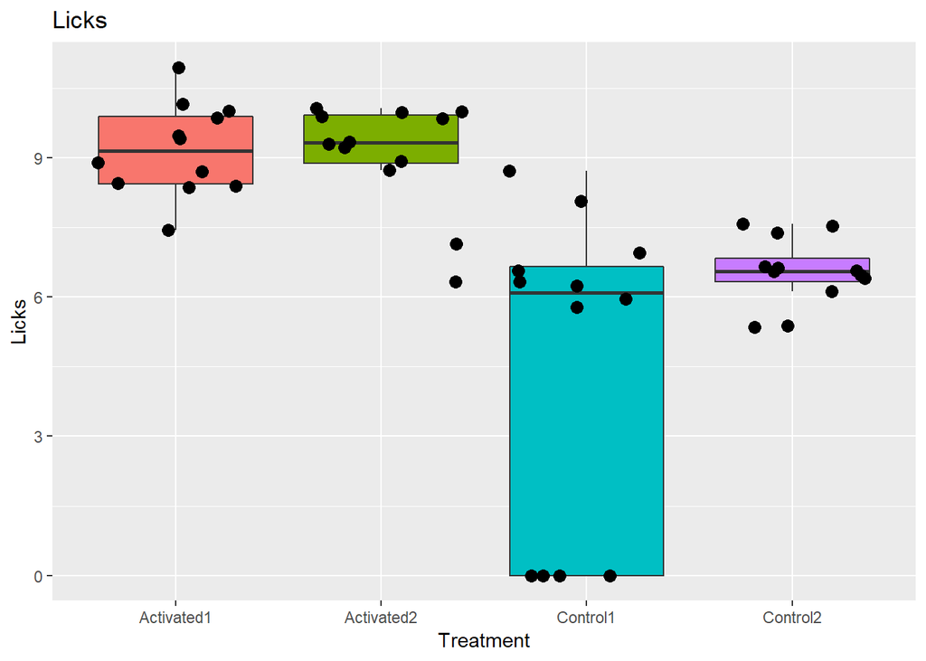

```
##
## **  Licks  **
##             Df Sum Sq Mean Sq F value   Pr(>F)
## Treatment    3  177.1   59.05   15.86 3.91e-07 ***
## Residuals   44  163.8    3.72
## ---
## Signif. codes:  0 '***' 0.001 '**' 0.01 '*' 0.05 '.' 0.1 ' ' 1
```

```r
DataPlot(f.summary,Type="Licks",SaveToFile=TRUE)
```

This function also returns a summary one-way ANOVA applied across treatments for the total licks through the given range.

This same function can be used to plot different behavior metrics. Current options are *Licks*, *Events*, *Durations*, *MinInt*, and *TimeBtw*. Measures of preference index (e.g., PI and EventPI) are available for choice experiments only. These options are discussed in the *ChoiceChamberAnalysis.html* documentation file.

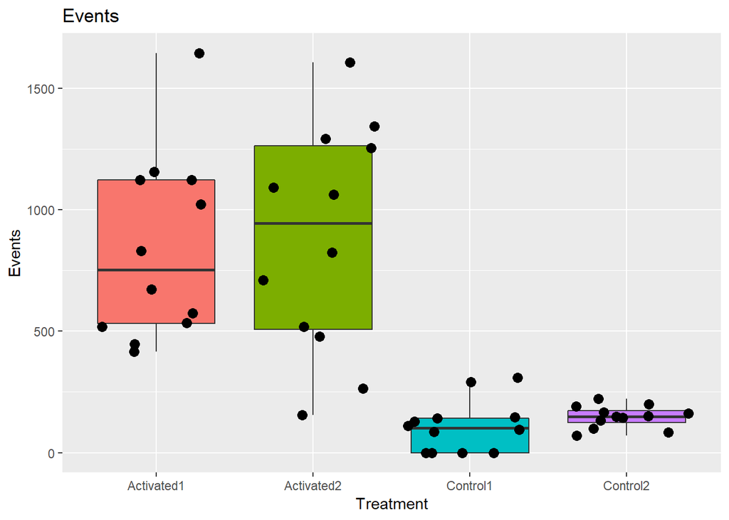

```
##
## **  Events  **
##             Df  Sum Sq Mean Sq F value   Pr(>F)
## Treatment    3 6472744 2157581   23.27 3.56e-09 ***
## Residuals   44 4080498   92739
## ---
## Signif. codes:  0 '***' 0.001 '**' 0.01 '*' 0.05 '.' 0.1 ' ' 1
```

```r
DataPlot(f.summary,Type="Events",SaveToFile=FALSE)
```

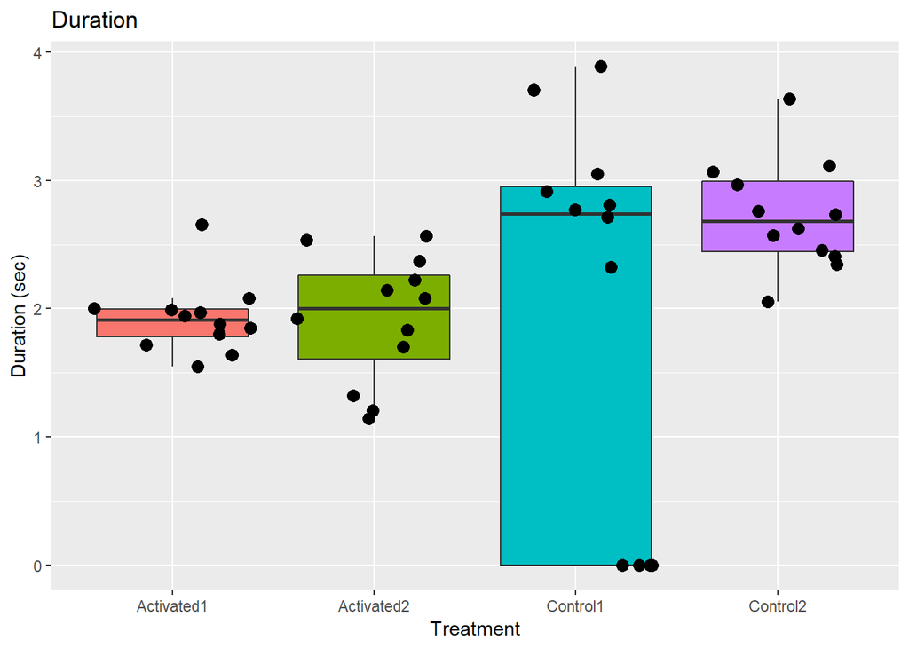

```
##
## **  Duration  **
##             Df Sum Sq Mean Sq F value Pr(>F)
## Treatment    3   5.49   1.829    2.53 0.0694 .
## Residuals   44  31.81   0.723
## ---
## Signif. codes:  0 '***' 0.001 '**' 0.01 '*' 0.05 '.' 0.1 ' ' 1
```

```r
DataPlot(f.summary,Type="Durations",SaveToFile=FALSE)
```

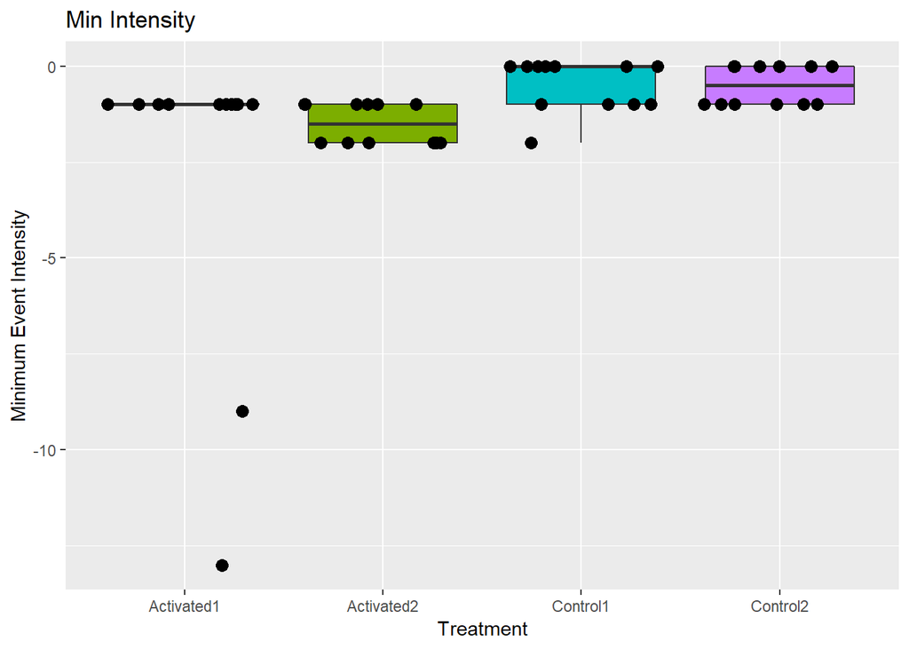

```
##
## **  Min Intensity  **
##             Df Sum Sq Mean Sq F value Pr(>F)
## Treatment    3  38.25   12.75   3.022 0.0396 *
## Residuals   44 185.67    4.22
## ---
## Signif. codes:  0 '***' 0.001 '**' 0.01 '*' 0.05 '.' 0.1 ' ' 1
```

```r
DataPlot(f.summary,Type="MinInt",SaveToFile=FALSE)
```

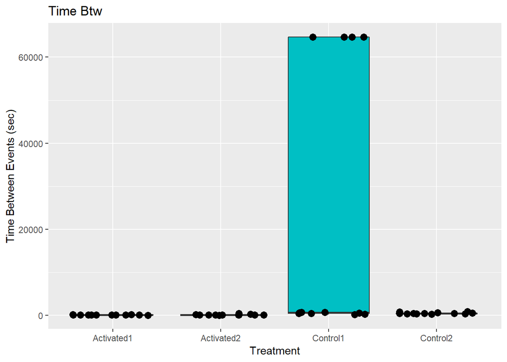

```
##
## **  Time Btw  **
##             Df    Sum Sq   Mean Sq F value  Pr(>F)
## Treatment    3 4.223e+09 1.408e+09   5.628 0.00236 **
## Residuals   44 1.101e+10 2.501e+08
## ---
## Signif. codes:  0 '***' 0.001 '**' 0.01 '*' 0.05 '.' 0.1 ' ' 1
```

```r
DataPlot(f.summary,Type="TimeBtw",SaveToFile=FALSE)
```

The same function is used to plot the *Feeding.Summary.Monitors()* results from choice experiments, but the output is separated into Well A and Well B, which have been adjusted for the PI.Multiplier and thus groups similar treatments.

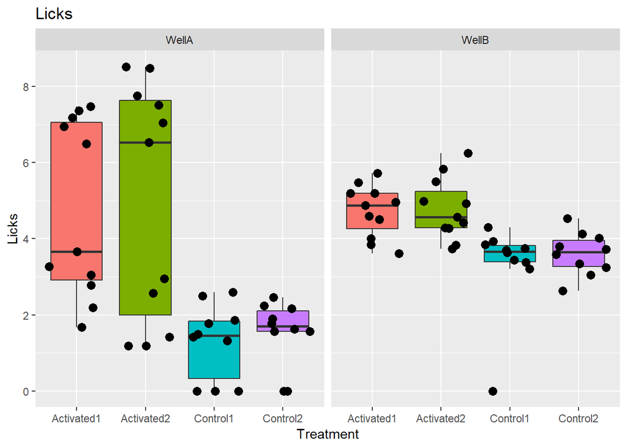

```
##
## **  Licks  **
##
## ANOVA results for Well A
##             Df Sum Sq Mean Sq F value   Pr(>F)
## Treatment    3  126.3   42.10   9.611 7.45e-05 ***
## Residuals   38  166.4    4.38
## ---
## Signif. codes:  0 '***' 0.001 '**' 0.01 '*' 0.05 '.' 0.1 ' ' 1
##
##
## ANOVA results for Well B
##             Df Sum Sq Mean Sq F value   Pr(>F)
## Treatment    3  17.93   5.977   8.395 0.000209 ***
## Residuals   38  27.06   0.712
## ---
## Signif. codes:  0 '***' 0.001 '**' 0.01 '*' 0.05 '.' 0.1 ' ' 1
```

```r
DataPlot(f.summary2,Type="Licks",SaveToFile=TRUE)
```

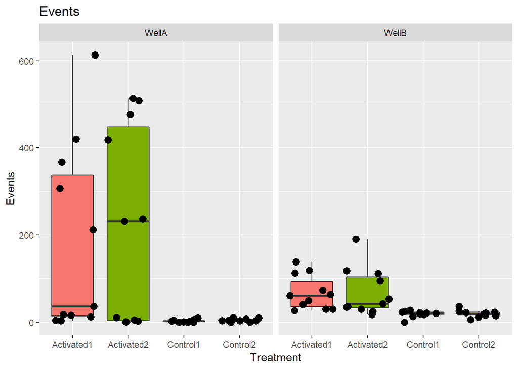

```
##
## **  Events  **
##
## ANOVA results for Well A
##             Df Sum Sq Mean Sq F value  Pr(>F)
## Treatment    3 414107  138036   5.404 0.00339 **
## Residuals   38 970654   25544
## ---
## Signif. codes:  0 '***' 0.001 '**' 0.01 '*' 0.05 '.' 0.1 ' ' 1
##
##
## ANOVA results for Well B
##             Df Sum Sq Mean Sq F value   Pr(>F)
## Treatment    3  25121    8374   6.971 0.000751 ***
## Residuals   38  45649    1201
## ---
## Signif. codes:  0 '***' 0.001 '**' 0.01 '*' 0.05 '.' 0.1 ' ' 1
```

```r
DataPlot(f.summary2,Type="Events",SaveToFile=TRUE)
```

Note that the range over which the data are analyzed, as well as the relevant parameter values use to identify interactions, are specified when the *Feeding.Summary.Monitors()* function is called. *DataPlot()* simply allows you to visualize those results.

A slightly more complicated version of these output plots is provided by the function *DivisionPlots()*, which divides the experiment (or the defined range) into a set number of divisions of equal durations and plots the relevant behavioral metric from the start of the range to the end of each division interval.

A box plot for each division is created, and a summary one-way ANOVA for each is output to the console. Because of the additional computation involved, the results from *Feeding.Summary.Monitors()* is not provided. This function must be called several times within the *DivisionPlots()* function. Therefore, a complete set of parameter arguments is required.

```
##
## **  Transformed Licks -- Range(min): (0,25)  **
##             Df Sum Sq Mean Sq F value   Pr(>F)
## Treatment    3  64.92  21.641   29.04 1.64e-10 ***
## Residuals   44  32.79   0.745
## ---
## Signif. codes:  0 '***' 0.001 '**' 0.01 '*' 0.05 '.' 0.1 ' ' 1
##
## **  Transformed Licks -- Range(min): (0,50)  **
##             Df Sum Sq Mean Sq F value   Pr(>F)
## Treatment    3  90.19  30.064   30.73 7.15e-11 ***
## Residuals   44  43.04   0.978
## ---
## Signif. codes:  0 '***' 0.001 '**' 0.01 '*' 0.05 '.' 0.1 ' ' 1
##
## **  Transformed Licks -- Range(min): (0,75)  **
##             Df Sum Sq Mean Sq F value   Pr(>F)
## Treatment    3 110.83   36.94   32.72 2.82e-11 ***
## Residuals   44  49.68    1.13
## ---
## Signif. codes:  0 '***' 0.001 '**' 0.01 '*' 0.05 '.' 0.1 ' ' 1
##
## **  Transformed Licks -- Range(min): (0,100)  **
##             Df Sum Sq Mean Sq F value Pr(>F)
## Treatment    3  120.5   40.18   40.55  1e-12 ***
## Residuals   44   43.6    0.99
## ---
## Signif. codes:  0 '***' 0.001 '**' 0.01 '*' 0.05 '.' 0.1 ' ' 1
```

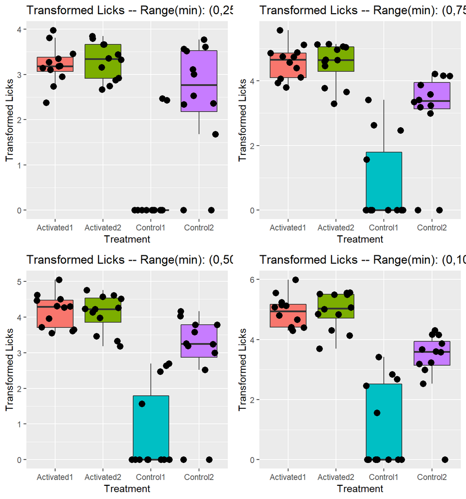

```r
#Function Definition
#DivisionPlots<-function(monitors,parameters,expDesign,range=c(0,0),divisions=1,Type="Licks",SaveToFile=FALSE,TransformLicks=TRUE)
DivisionPlots(monitors.single,p.single,expDesign=expDesign,range=c(0,100),divisions=4,Type="Licks")
```

```
##
## **  Transformed Total Licks -- Range(min): (0,25)  **
##             Df Sum Sq Mean Sq F value  Pr(>F)
## Treatment    3  25.83   8.609   5.655 0.00264 **
## Residuals   38  57.85   1.522
## ---
## Signif. codes:  0 '***' 0.001 '**' 0.01 '*' 0.05 '.' 0.1 ' ' 1
##
## **  Transformed Total Licks -- Range(min): (0,50)  **
##             Df Sum Sq Mean Sq F value   Pr(>F)
## Treatment    3  36.37  12.122    7.36 0.000525 ***
## Residuals   38  62.58   1.647
## ---
## Signif. codes:  0 '***' 0.001 '**' 0.01 '*' 0.05 '.' 0.1 ' ' 1
##
## **  Transformed Total Licks -- Range(min): (0,75)  **
##             Df Sum Sq Mean Sq F value  Pr(>F)
## Treatment    3  45.11  15.036   7.608 0.00042 ***
## Residuals   38  75.10   1.976
## ---
## Signif. codes:  0 '***' 0.001 '**' 0.01 '*' 0.05 '.' 0.1 ' ' 1
##
## **  Transformed Total Licks -- Range(min): (0,100)  **
##             Df Sum Sq Mean Sq F value   Pr(>F)
## Treatment    3  55.46  18.487   7.074 0.000683 ***
## Residuals   38  99.31   2.613
## ---
## Signif. codes:  0 '***' 0.001 '**' 0.01 '*' 0.05 '.' 0.1 ' ' 1
```

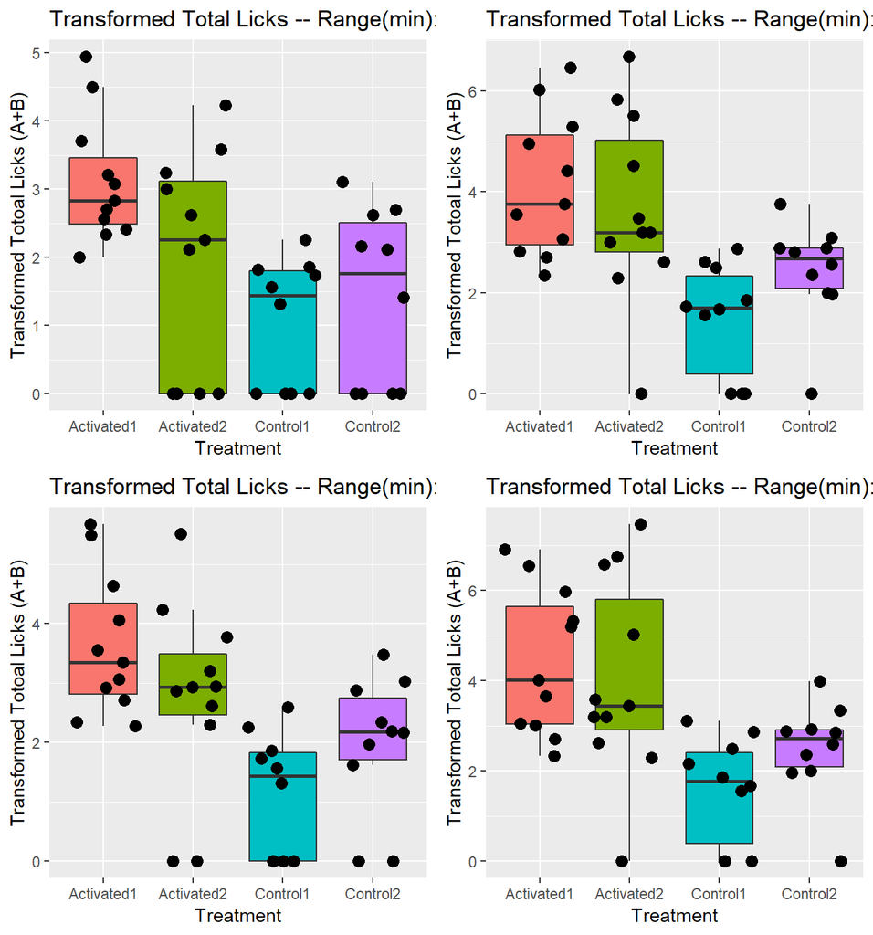

```r
DivisionPlots(monitors.choice,p.choice.list,expDesign,range=c(0,100),divisions=4,Type="Licks")
```

For choice experiments, licks are combined in a reasonable way from both wells. The one-way ANOVA is also executed on total licks. For choice experiments, these plots are likely to have limited use.

As with *DataPlot()* different behavior measures can be visualized by changing the *Type* parameter. Current options are *Licks*, *Events*, *Durations*, *MinInt*, and *TimeBtw*. Measures of preference index (e.g., PI and EventPI) are available for choice experiments only. These options are discussed in the *ChoiceChamberAnalysis.html* documentation file.

To visualize binned data, the *BinnedDataPlot()* function parallels the *DataPlot()* function, but it instead takes as its first argument the data frame output from *BinnedFeeding.Summary.Monitors()*.

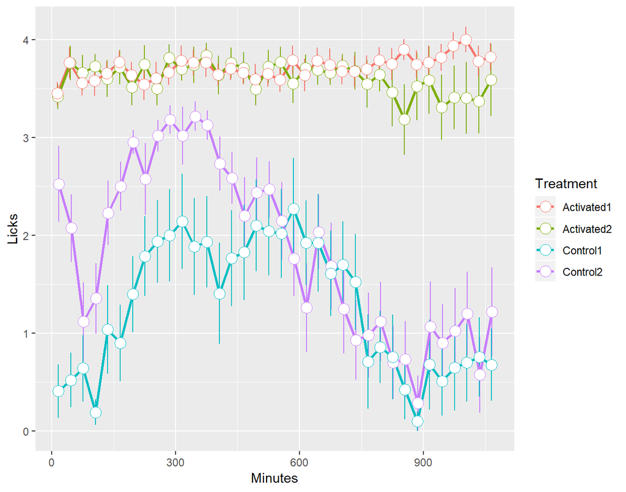

```
## ** Interval specific ANOVA results **
```

```
## $`[0,30]`
##             Df Sum Sq Mean Sq F value   Pr(>F)
## Treatment    3  73.41  24.470   31.88 4.17e-11 ***
## Residuals   44  33.78   0.768
## ---
## Signif. codes:  0 '***' 0.001 '**' 0.01 '*' 0.05 '.' 0.1 ' ' 1
##
## $`(30,60]`
##             Df Sum Sq Mean Sq F value   Pr(>F)
## Treatment    3  87.55  29.184   38.18 2.61e-12 ***
## Residuals   44  33.63   0.764
## ---
## Signif. codes:  0 '***' 0.001 '**' 0.01 '*' 0.05 '.' 0.1 ' ' 1
##
## $`(60,90]`
##             Df Sum Sq Mean Sq F value   Pr(>F)
## Treatment    3  91.02  30.341   31.01 6.27e-11 ***
## Residuals   44  43.05   0.978
## ---
## Signif. codes:  0 '***' 0.001 '**' 0.01 '*' 0.05 '.' 0.1 ' ' 1
##
## $`(90,120]`
##             Df Sum Sq Mean Sq F value   Pr(>F)
## Treatment    3 107.92   35.97   63.46 5.08e-16 ***
## Residuals   44  24.94    0.57
## ---
## Signif. codes:  0 '***' 0.001 '**' 0.01 '*' 0.05 '.' 0.1 ' ' 1
##
## $`(120,150]`
##             Df Sum Sq Mean Sq F value   Pr(>F)
## Treatment    3  56.40  18.801   17.37 1.38e-07 ***
## Residuals   44  47.63   1.082
## ---
## Signif. codes:  0 '***' 0.001 '**' 0.01 '*' 0.05 '.' 0.1 ' ' 1
##
## $`(150,180]`
##             Df Sum Sq Mean Sq F value   Pr(>F)
## Treatment    3  65.58  21.861   28.05 2.69e-10 ***
## Residuals   44  34.29   0.779
## ---
```

[output cut: 196 more lines]

```
## Signif. codes:  0 '***' 0.001 '**' 0.01 '*' 0.05 '.' 0.1 ' ' 1
##
## $`(1020,1050]`
##             Df Sum Sq Mean Sq F value   Pr(>F)
## Treatment    3 102.99   34.33   25.52 1.02e-09 ***
## Residuals   44  59.19    1.35
## ---
## Signif. codes:  0 '***' 0.001 '**' 0.01 '*' 0.05 '.' 0.1 ' ' 1
##
## $`(1050,1079.99]`
##             Df Sum Sq Mean Sq F value   Pr(>F)
## Treatment    3  93.44  31.146   20.91 1.43e-08 ***
## Residuals   44  65.52   1.489
## ---
## Signif. codes:  0 '***' 0.001 '**' 0.01 '*' 0.05 '.' 0.1 ' ' 1
```

```r
# Function Definition
#BinnedDataPlot<-function(binnedDataResult,Type="Licks",SaveToFile=FALSE)
BinnedDataPlot(f.binsummary,Type="Licks",SaveToFile=TRUE)
```

For each bin, a one-way ANOVA summary across treatments is output to the console. Note that in this example the two treatments in which specific fly neurons were activated exhibited a persistant increase in feeding throughout experiment. Control animals exhibited a characteristic increase in feeding near the start of the experiment, which coincided with their evening meal, which decreased with time and eventually became quite low in darkness.

For choice experiments, the plots are faceted such that feeding interactions in Well A are presented separately from those in Well B. Remember, these have been corrected for PI.Multiplier.

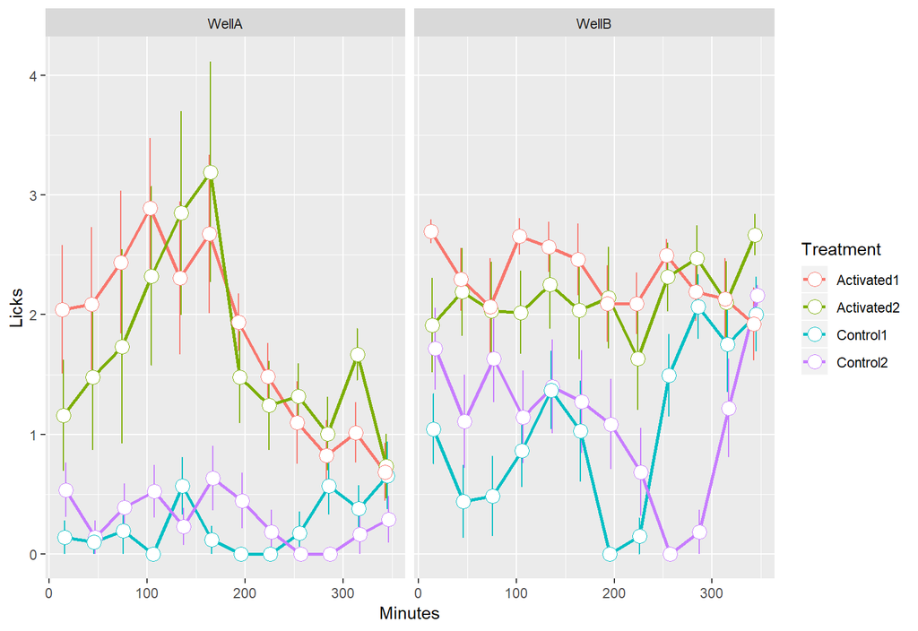

```
##
##
##
## ** Interval specific ANOVA results for Well A **
##
## $`[0,30]`
##             Df Sum Sq Mean Sq F value  Pr(>F)
## Treatment    3  21.79   7.264   4.467 0.00879 **
## Residuals   38  61.80   1.626
## ---
## Signif. codes:  0 '***' 0.001 '**' 0.01 '*' 0.05 '.' 0.1 ' ' 1
##
## $`(30,60]`
##             Df Sum Sq Mean Sq F value  Pr(>F)
## Treatment    3  30.95  10.318   4.393 0.00949 **
## Residuals   38  89.25   2.349
## ---
## Signif. codes:  0 '***' 0.001 '**' 0.01 '*' 0.05 '.' 0.1 ' ' 1
##
## $`(60,90]`
##             Df Sum Sq Mean Sq F value Pr(>F)
## Treatment    3  36.56  12.188   3.901 0.0159 *
## Residuals   38 118.72   3.124
## ---
## Signif. codes:  0 '***' 0.001 '**' 0.01 '*' 0.05 '.' 0.1 ' ' 1
##
## $`(90,120]`
##             Df Sum Sq Mean Sq F value Pr(>F)
## Treatment    3  60.65  20.215   7.415  5e-04 ***
## Residuals   38 103.59   2.726
## ---
## Signif. codes:  0 '***' 0.001 '**' 0.01 '*' 0.05 '.' 0.1 ' ' 1
##
## $`(120,150]`
##             Df Sum Sq Mean Sq F value  Pr(>F)
## Treatment    3  51.86  17.286   4.987 0.00515 **
## Residuals   38 131.72   3.466
## ---
## Signif. codes:  0 '***' 0.001 '**' 0.01 '*' 0.05 '.' 0.1 ' ' 1
##
```

[output cut: 116 more lines]

```
##             Df Sum Sq Mean Sq F value   Pr(>F)
## Treatment    3  33.39  11.129   17.35 2.94e-07 ***
## Residuals   38  24.37   0.641
## ---
## Signif. codes:  0 '***' 0.001 '**' 0.01 '*' 0.05 '.' 0.1 ' ' 1
##
## $`(300,330]`
##             Df Sum Sq Mean Sq F value Pr(>F)
## Treatment    3   5.59   1.864   1.287  0.293
## Residuals   38  55.04   1.448
##
## $`(330,358.98678]`
##             Df Sum Sq Mean Sq F value Pr(>F)
## Treatment    3  3.659  1.2197   2.036  0.125
## Residuals   38 22.765  0.5991
```

```r
BinnedDataPlot(f.binsummary2,Type="Licks",SaveToFile=FALSE)
```

In this experiment, activated flies received optostimulation when feeding from Well A, but not from Well B for the first 180 minutes of the experiment. For the second 180 minutes, no stimulation was provided. The binned data clearly show that optostimulation specifically promotes feeding from Well A, and this preference declines to near control levels by 360 min (P=0.592 from the one-way ANOVA for the final interval in Well A).

As with *DataPlot()* different behavior measures can be visualized by changing the *Type* parameter. Current options are *Licks*, *Events*, *Durations*, *MinInt*, and *TimeBtw*. Measures of preference index (e.g., PI and EventPI) are available for choice experiments only.

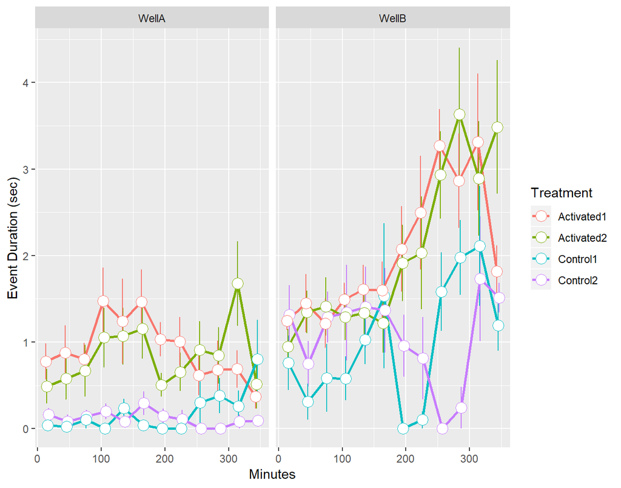

```
##
##
##
## ** Interval specific ANOVA results for Well A **
##
## $`[0,30]`
##             Df Sum Sq Mean Sq F value  Pr(>F)
## Treatment    3  3.484  1.1613   4.512 0.00838 **
## Residuals   38  9.780  0.2574
## ---
## Signif. codes:  0 '***' 0.001 '**' 0.01 '*' 0.05 '.' 0.1 ' ' 1
##
## $`(30,60]`
##             Df Sum Sq Mean Sq F value Pr(>F)
## Treatment    3  5.298  1.7660   3.693 0.0199 *
## Residuals   38 18.169  0.4781
## ---
## Signif. codes:  0 '***' 0.001 '**' 0.01 '*' 0.05 '.' 0.1 ' ' 1
##
## $`(60,90]`
##             Df Sum Sq Mean Sq F value Pr(>F)
## Treatment    3   4.06  1.3533   3.406 0.0272 *
## Residuals   38  15.10  0.3973
## ---
## Signif. codes:  0 '***' 0.001 '**' 0.01 '*' 0.05 '.' 0.1 ' ' 1
##
## $`(90,120]`
##             Df Sum Sq Mean Sq F value  Pr(>F)
## Treatment    3  15.37   5.124   6.505 0.00116 **
## Residuals   38  29.93   0.788
## ---
## Signif. codes:  0 '***' 0.001 '**' 0.01 '*' 0.05 '.' 0.1 ' ' 1
##
## $`(120,150]`
##             Df Sum Sq Mean Sq F value Pr(>F)
## Treatment    3  10.67   3.557   3.378  0.028 *
## Residuals   38  40.02   1.053
## ---
## Signif. codes:  0 '***' 0.001 '**' 0.01 '*' 0.05 '.' 0.1 ' ' 1
##
```

[output cut: 106 more lines]

```
## Residuals   38 119.86   3.154
## ---
## Signif. codes:  0 '***' 0.001 '**' 0.01 '*' 0.05 '.' 0.1 ' ' 1
##
## $`(300,330]`
##             Df Sum Sq Mean Sq F value Pr(>F)
## Treatment    3  16.27   5.422   0.996  0.405
## Residuals   38 206.93   5.445
##
## $`(330,358.98678]`
##             Df Sum Sq Mean Sq F value Pr(>F)
## Treatment    3  33.51  11.170    4.96 0.0053 **
## Residuals   38  85.58   2.252
## ---
## Signif. codes:  0 '***' 0.001 '**' 0.01 '*' 0.05 '.' 0.1 ' ' 1
```

```r
BinnedDataPlot(f.binsummary2,Type="Durations",SaveToFile=FALSE)
```

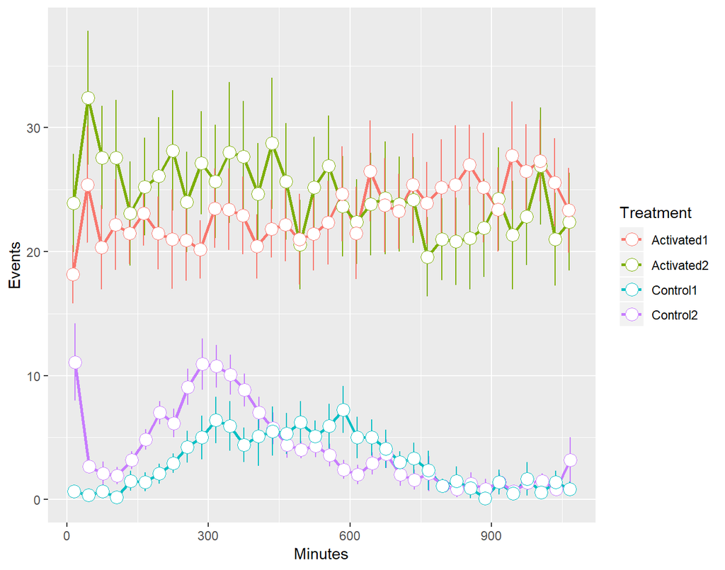

```
## ** Interval specific ANOVA results **
```

```
## $`[0,30]`
##             Df Sum Sq Mean Sq F value   Pr(>F)
## Treatment    3   3610  1203.3   12.89 3.56e-06 ***
## Residuals   44   4108    93.4
## ---
## Signif. codes:  0 '***' 0.001 '**' 0.01 '*' 0.05 '.' 0.1 ' ' 1
##
## $`(30,60]`
##             Df Sum Sq Mean Sq F value  Pr(>F)
## Treatment    3   9347  3115.6   20.29 2.1e-08 ***
## Residuals   44   6757   153.6
## ---
## Signif. codes:  0 '***' 0.001 '**' 0.01 '*' 0.05 '.' 0.1 ' ' 1
##
## $`(60,90]`
##             Df Sum Sq Mean Sq F value   Pr(>F)
## Treatment    3   6448  2149.2   23.91 2.47e-09 ***
## Residuals   44   3955    89.9
## ---
## Signif. codes:  0 '***' 0.001 '**' 0.01 '*' 0.05 '.' 0.1 ' ' 1
##
## $`(90,120]`
##             Df Sum Sq Mean Sq F value   Pr(>F)
## Treatment    3   7011  2336.9   21.83 8.25e-09 ***
## Residuals   44   4711   107.1
## ---
## Signif. codes:  0 '***' 0.001 '**' 0.01 '*' 0.05 '.' 0.1 ' ' 1
##
## $`(120,150]`
##             Df Sum Sq Mean Sq F value   Pr(>F)
## Treatment    3   4812  1603.9   21.29 1.14e-08 ***
## Residuals   44   3315    75.3
## ---
## Signif. codes:  0 '***' 0.001 '**' 0.01 '*' 0.05 '.' 0.1 ' ' 1
##
## $`(150,180]`
##             Df Sum Sq Mean Sq F value   Pr(>F)
## Treatment    3   5411  1803.7   25.46 1.05e-09 ***
## Residuals   44   3118    70.9
## ---
```

[output cut: 196 more lines]

```
## Signif. codes:  0 '***' 0.001 '**' 0.01 '*' 0.05 '.' 0.1 ' ' 1
##
## $`(1020,1050]`
##             Df Sum Sq Mean Sq F value   Pr(>F)
## Treatment    3   6024  2008.1   24.14 2.17e-09 ***
## Residuals   44   3659    83.2
## ---
## Signif. codes:  0 '***' 0.001 '**' 0.01 '*' 0.05 '.' 0.1 ' ' 1
##
## $`(1050,1079.99]`
##             Df Sum Sq Mean Sq F value  Pr(>F)
## Treatment    3   5267  1755.6   18.98 4.8e-08 ***
## Residuals   44   4071    92.5
## ---
## Signif. codes:  0 '***' 0.001 '**' 0.01 '*' 0.05 '.' 0.1 ' ' 1
```

```r
BinnedDataPlot(f.binsummary,Type="Events",SaveToFile=FALSE)
```

## Other Useful Functions

You can plot the total licks over the duration of an experiment for each Well, grouped by DFM (and, for choice experiments, colored by Well) using the *PlotTotalLicks.Monitors(monitors, p, range=c(0,0),TransformLicks=TRUE)* function. Arguments are similar to those for *Feeding.Summary.Montiors()*. This is useful for identifying specific DFM effects, which may lead to overall higher or lower feeding values for all wells in a specific DFM. For choice experiments, Wells are corrected for the *PI.Multiplier* and therefore are grouped as “Well A” and “Well B”.

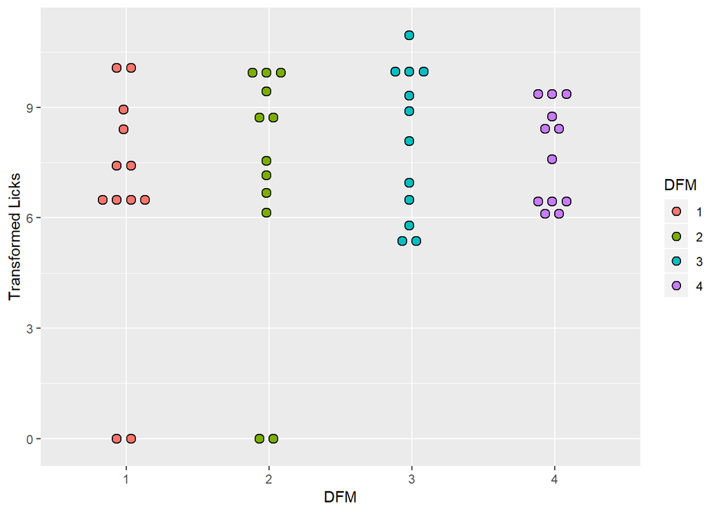

```r
PlotTotalLicks.Monitors(monitors.single,p.single)
```

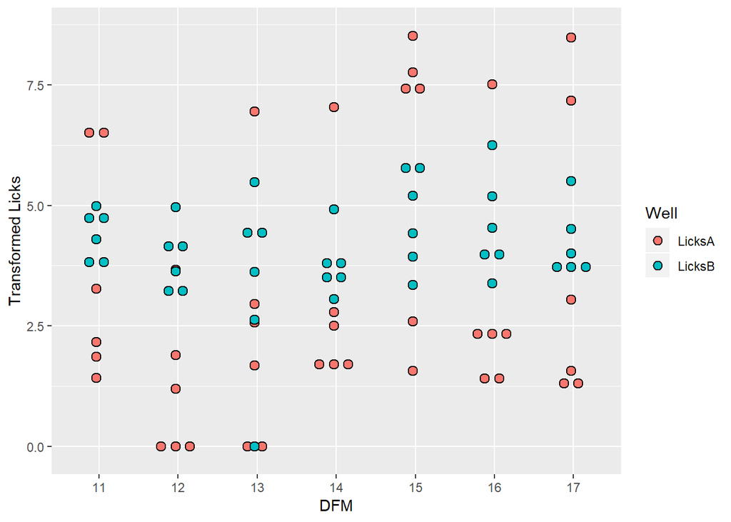

```r
PlotTotalLicks.Monitors(monitors.choice,p.choice.list)
```

## Function Definition Reference

Listed below are the functions used in this document along with their argument list showing optional parameters and their default values. You should know what each of these functions does and what each argument represents before moving on to the remaining documentation. It is important that these functions, and the larger set of R Code for the FLIC, are not treated as a black box. In our experience the FLIC system provides remarkable insights, but the data sets are large and complex and must be managed carefully to ensure that mistakes are avoided.

```r
BinnedFeeding.Summary.Monitors(monitors,parameters,binsize.min=30,expDesign=NA,range=c(0,0),SaveToFile=TRUE,TransformLicks=TRUE,filename="BinnedSummary")

BinnedDataPlot(binnedDataResult,Type="Licks",SaveToFile=FALSE)

DataPlot(summaryResults,Type="Licks",SaveToFile=FALSE)

DivisionPlots(monitors,parameters,expDesign,range=c(0,0),divisions=1,Type="Licks",SaveToFile=FALSE,TransformLicks=TRUE)

Feeding.Summary.Monitors(monitors,parameters,expDesign=NA,range=c(0,0),SaveToFile=TRUE,TransformLicks=TRUE,filename="FeedingSummary")

OutputData.Monitors(monitors,parameters,expDesign=NA,range=c(0,0),Type="BaselinedData",filename=NA)

PlotTotalLicks.Monitors(monitors, p, range=c(0,0),TransformLicks=TRUE)
```